# Assignment - Course Project 1

Vitor Efigênio Neto

6 de fevereiro de 2016

## Instructions

This assignment uses data from the UC Irvine Machine Learning Repository, a popular repository for machine learning datasets. In particular, we will be using the “Individual household electric power consumption Data Set” which I have made available on the course web site:

- **Dataset**: Electric power consumption [20Mb]
- **Description**: Measurements of electric power consumption in one household with a one-minute sampling rate over a period of almost 4 years. Different electrical quantities and some sub-metering values are available.

The following descriptions of the 9 variables in the dataset are taken from the UCI web site:

1. **Date**: Date in format dd/mm/yyyy
2. **Time**: time in format hh:mm:ss
3. **Global_active_power**: household global minute-averaged active power (in kilowatt)
4. **Global_reactive_power**: household global minute-averaged reactive power (in kilowatt)
5. **Voltage**: minute-averaged voltage (in volt)
6. **Global_intensity**: household global minute-averaged current intensity (in ampere)
7. **Sub_metering_1**: energy sub-metering No. 1 (in watt-hour of active energy). It corresponds to the kitchen, containing mainly a dishwasher, an oven and a microwave (hot plates are not electric but gas powered).
8. **Sub_metering_2**: energy sub-metering No. 2 (in watt-hour of active energy). It corresponds to the laundry room, containing a washing-machine, a tumble-drier, a refrigerator and a light.
9. **Sub_metering_3**: energy sub-metering No. 3 (in watt-hour of active energy). It corresponds to an electric water-heater and an air-conditioner.

## Making Plots

Our overall goal here is simply to examine how household energy usage varies over a 2-day period in February, 2007. Your task is to reconstruct the following plots below, all of which were constructed using the base plotting system.

First you will need to fork and clone the following GitHub repository: https://github.com/rdpeng/ExData_Plotting1

For each plot you should

- Construct the plot and save it to a PNG file with a width of 480 pixels and a height of 480 pixels.
- Name each of the plot files as plot1.png, plot2.png, etc.
- Create a separate R code file (plot1.R, plot2.R, etc.) that constructs the corresponding plot, i.e. code in plot1.R constructs the plot1.png plot. Your code file should include code for reading the data so that the plot can be fully reproduced. You should also include the code that creates the PNG file.
- Add the PNG file and R code file to your git repository

When you are finished with the assignment, push your git repository to GitHub so that the GitHub version of your repository is up to date. There should be four PNG files and four R code files.

The four plots that you will need to construct are shown below.

### Loading Data

```r
# Full Data
power_full_data <- read.table("household_power_consumption.txt", header=T, sep=';', na.strings="?", nrows=2075259, check.names=F, stringsAsFactors=F, comment.char="", quote='\"')

power_full_data$Date <- as.Date(power_full_data$Date, format="%d/%m/%Y")

# 2-days February 2007
two_days <- subset(power_full_data, subset=(Date >= "2007-02-01" & Date <= "2007-02-02"))
rm(power_full_data)

# Creating a Datetime parameter
datetime <- paste(as.Date(two_days$Date), two_days$Time)
two_days$Datetime <- as.POSIXct(datetime)

head(two_days)
```

```
##             Date     Time Global_active_power Global_reactive_power
## 66637 2007-02-01 00:00:00               0.326                 0.128
## 66638 2007-02-01 00:01:00               0.326                 0.130
## 66639 2007-02-01 00:02:00               0.324                 0.132
## 66640 2007-02-01 00:03:00               0.324                 0.134
## 66641 2007-02-01 00:04:00               0.322                 0.130
## 66642 2007-02-01 00:05:00               0.320                 0.126
##       Voltage Global_intensity Sub_metering_1 Sub_metering_2
## 66637  243.15              1.4              0              0
## 66638  243.32              1.4              0              0
## 66639  243.51              1.4              0              0
## 66640  243.90              1.4              0              0
## 66641  243.16              1.4              0              0
## 66642  242.29              1.4              0              0
##       Sub_metering_3            Datetime
## 66637              0 2007-02-01 00:00:00
## 66638              0 2007-02-01 00:01:00
## 66639              0 2007-02-01 00:02:00
## 66640              0 2007-02-01 00:03:00
## 66641              0 2007-02-01 00:04:00
## 66642              0 2007-02-01 00:05:00
```

### Plot 1

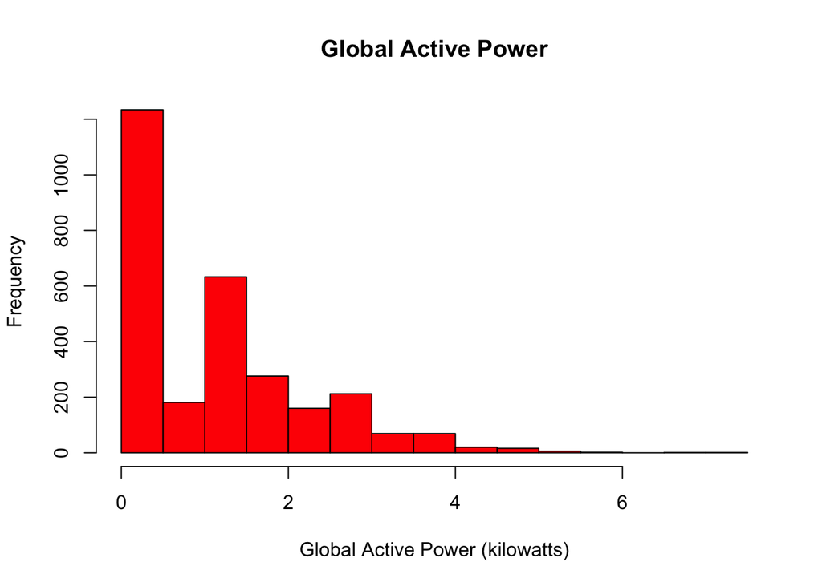

```r
hist(two_days$Global_active_power, main="Global Active Power", xlab="Global Active Power (kilowatts)", col="red")
```

Export to PNG file

```r
dev.copy(png, file="plot1.png", height=480, width=480)
```

```r
dev.off()
```

## Plot 2

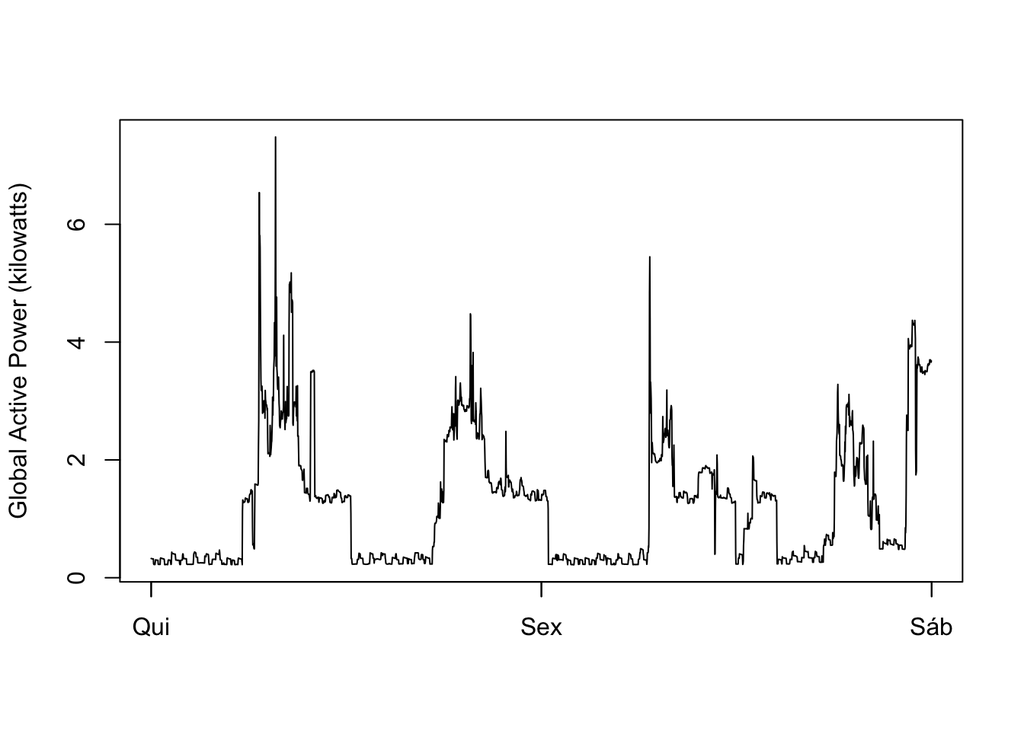

```r
plot(two_days$Global_active_power~two_days$Datetime, type="l",ylab="Global Active Power (kilowatts)", xlab="")
```

Export to PNG file

```r
dev.copy(png, file="plot2.png", height=480, width=480)
```

```r
dev.off()
```

## Plot 3

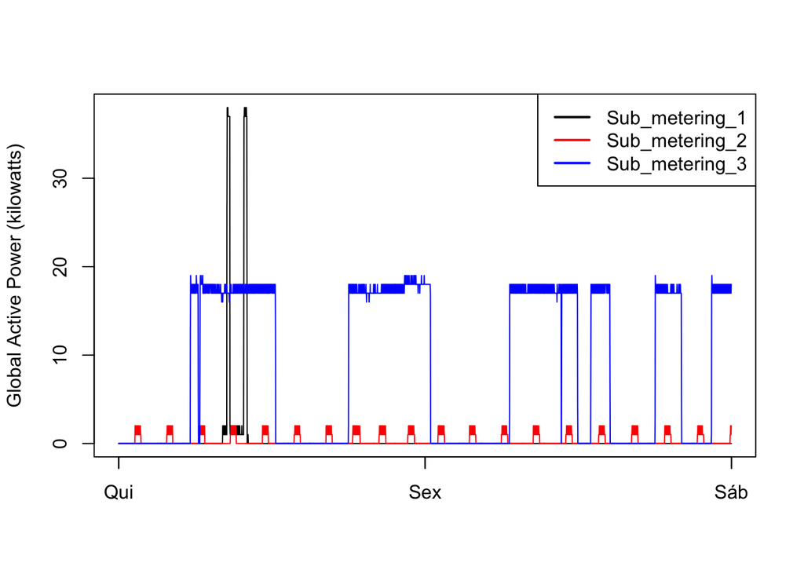

```r
with(two_days, {
    plot(Sub_metering_1~Datetime, type="l",
         ylab="Global Active Power (kilowatts)", xlab="")
    lines(Sub_metering_2~Datetime,col='Red')
    lines(Sub_metering_3~Datetime,col='Blue')
})
legend("topright", col=c("black", "red", "blue"), lty=1, lwd=2,
       legend=c("Sub_metering_1", "Sub_metering_2", "Sub_metering_3"))
```

Export to PNG file

```r
dev.copy(png, file="plot3.png", height=480, width=480)
```

```r
dev.off()
```

## Plot 4

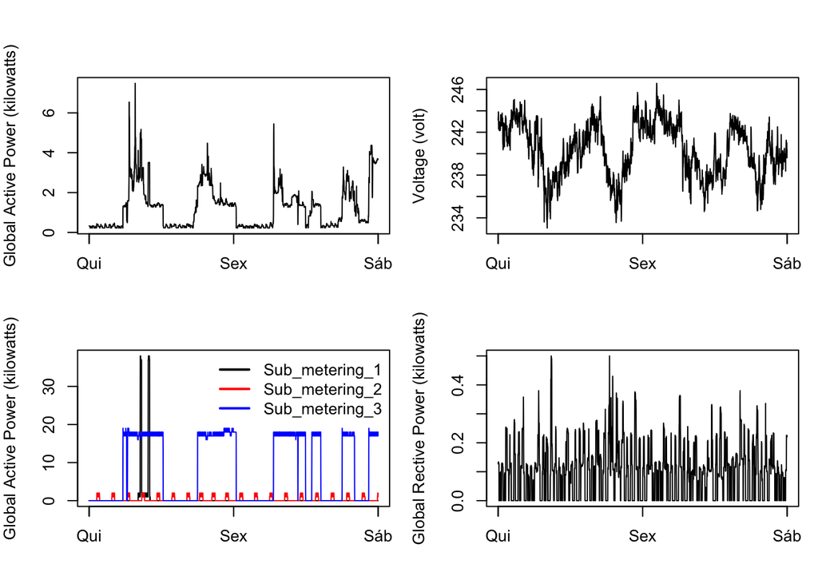

```r
par(mfrow=c(2,2), mar=c(4,4,2,1), oma=c(0,0,2,0))
with(two_days, {
    plot(Global_active_power~Datetime, type="l",
         ylab="Global Active Power (kilowatts)", xlab="")
    plot(Voltage~Datetime, type="l",
         ylab="Voltage (volt)", xlab="")
    plot(Sub_metering_1~Datetime, type="l",
         ylab="Global Active Power (kilowatts)", xlab="")
    lines(Sub_metering_2~Datetime,col='Red')
    lines(Sub_metering_3~Datetime,col='Blue')
    legend("topright", col=c("black", "red", "blue"), lty=1, lwd=2, bty="n",
           legend=c("Sub_metering_1", "Sub_metering_2", "Sub_metering_3"))
    plot(Global_reactive_power~Datetime, type="l",
         ylab="Global Rective Power (kilowatts)",xlab="")
})
```

Export to PNG file

```r
dev.copy(png, file="plot4.png", height=480, width=480)
```

```r
dev.off()
```